# Analiza jakości zajęć na Wydziale Z-Nauk

Semestr 2022–2023/lato

Komisja ds. jakości kształcenia

01/01/2024

## Opis procedury zbierania i analizy danych

Ankieta oceniająca jakość studiowania w PSW jest udostępniana studentom w systemie Wirtualny Dziekanat. Wypełnione ankiety są eksportowane do pliku w formacie CSV, a analiza statystyczna jest wykonywana za pomocą autorskiego programu (w języku R) stworzonego przez członków zespołu d/s analizy jakości. **Dzięki zautomatyzowaniu przetwarzania danych (w miejsce używania do tego celu oprogramowania biurowego) udało się znacząco obniżyć koszty, zmniejszyć liczbę błędów oraz zapewnić 100% powtarzalność analiz**.

Wyżej wspomniana ankieta zawiera 9 zmiennych oceniających jakość zajęć prowadzone na PSW: `o1` – Sposób przedstawienia treści zajęć; `o2` – Wykorzystanie czasu zajęć; `o3` – Przedstawienie warunków uzyskania zaliczenia; `o4` – Kompetencje merytoryczne wykładowcy do prowadzenia zajęć; `o5` – Postawa wykładowcy wobec studentów; `o6` – Dostępność wykładowcy dla studentów; `o7` – Właściwy dobór zagadnień znacząco poszerzył moją wiedzę i umiejętności; `o8` – Sposób prowadzenia zajęć umożliwiał łączenie własnej wiedzy i doświadczeń z nową wiedzą i umiejętnościami; `o9` – Sposób prowadzenia zajęć umożliwiał rozwój kompetencji społecznych. Na każde pytanie możliwa było odpowiedź od bardzo źle do bardzo dobrze. Ponadto pytanie `o10` ocenia stopień zainteresowania studenta zajęciami (w skali od *uważam za bardzo mało interesujący* do *uważam za bardzo interesujący*)

Formularz ankiety znajduje się w Załączniku.

## Analiza wstępna danych

Łączna zebrano 11878 ankiet. Zestawienie w podziale na liczbę ankiet wg lat studiów zamieszczono w poniższej tabeli.

| rok | liczba ankiet |
| --- | --- |
| 0 | 183 |
| 1 | 8998 |
| 2 | 2539 |
| 3 | 158 |

Umownie rok `0` oznacza respondentów Pielęgniarstwa w ramach studiów pomostowych (PP).

Zestawienie w podziale na liczbę ankiet wg miejsca studiowania zamieszczono w poniższej tabeli.

| miejsce | liczba ankiet |
| --- | --- |
| GDA | 4231 |
| KOS | 1490 |
| KWI | 5956 |
| TOR | 201 |

W 2022-2023/L na wydziale Z-Nauk oceniono 114 prowadzących zajęcia.

## Zbiorcza ocena zajęć

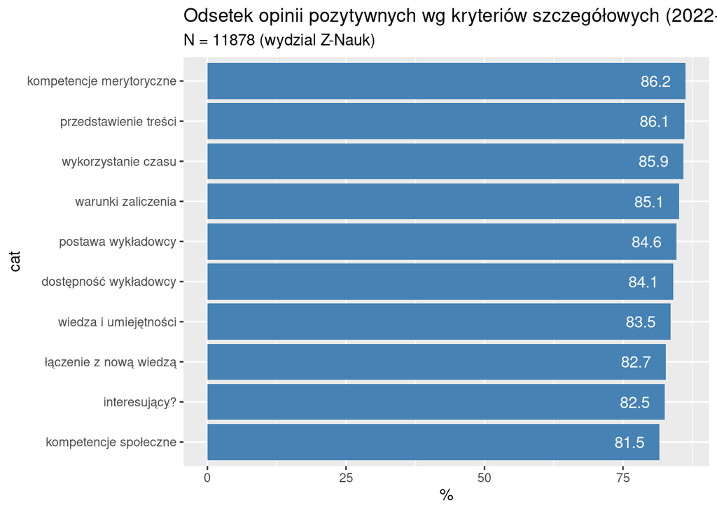

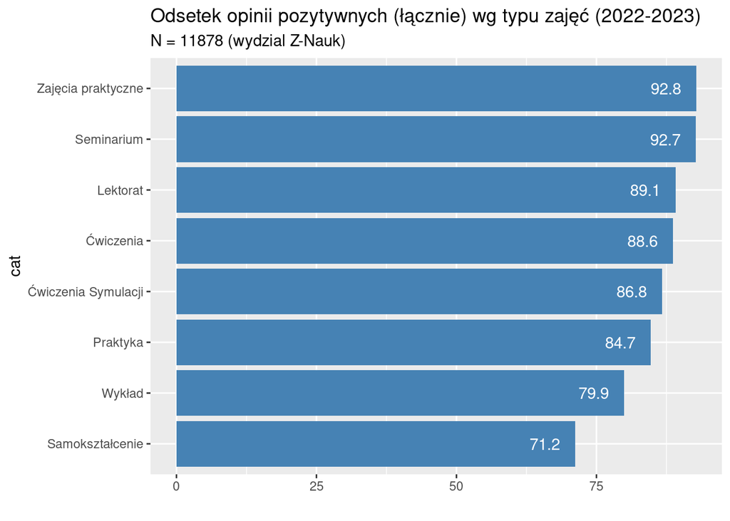

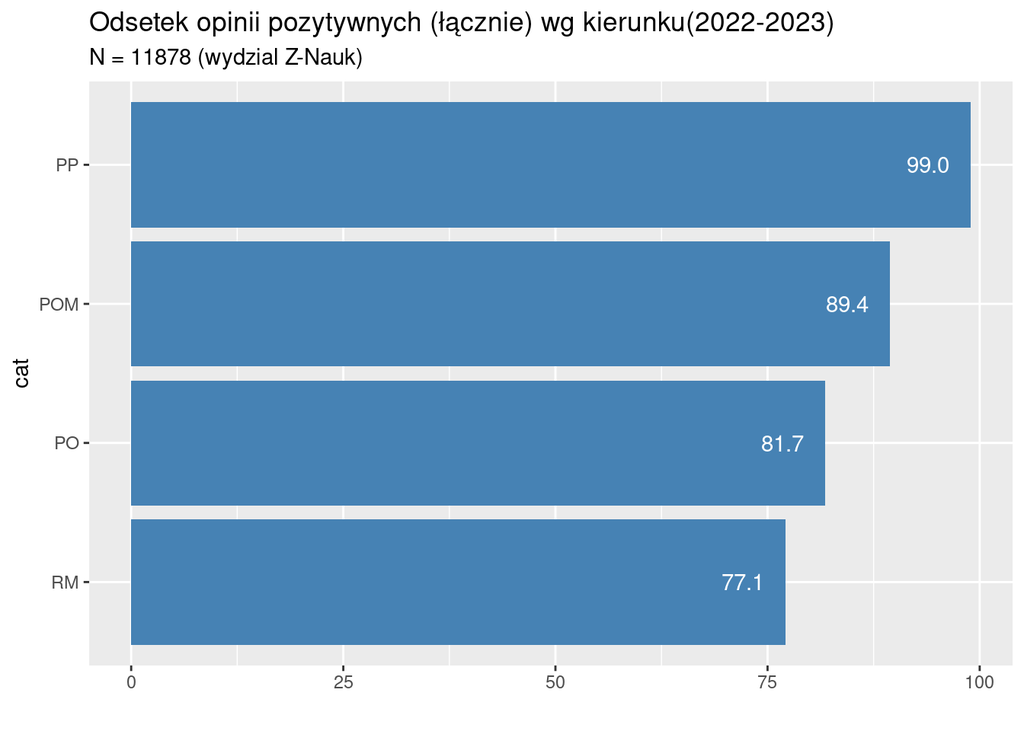

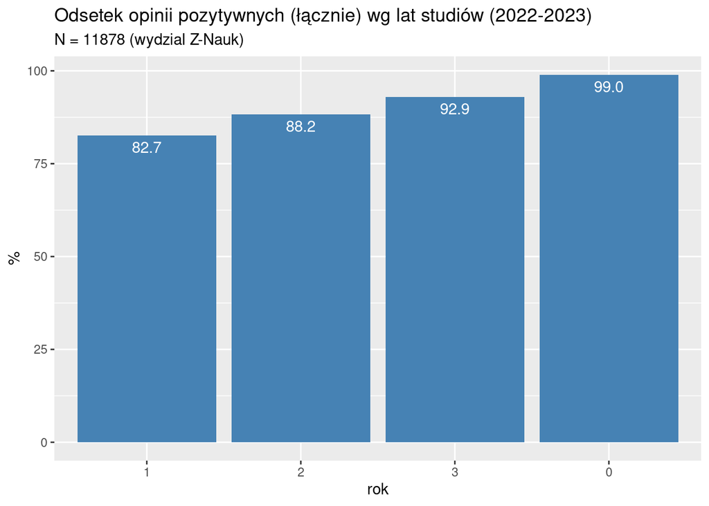

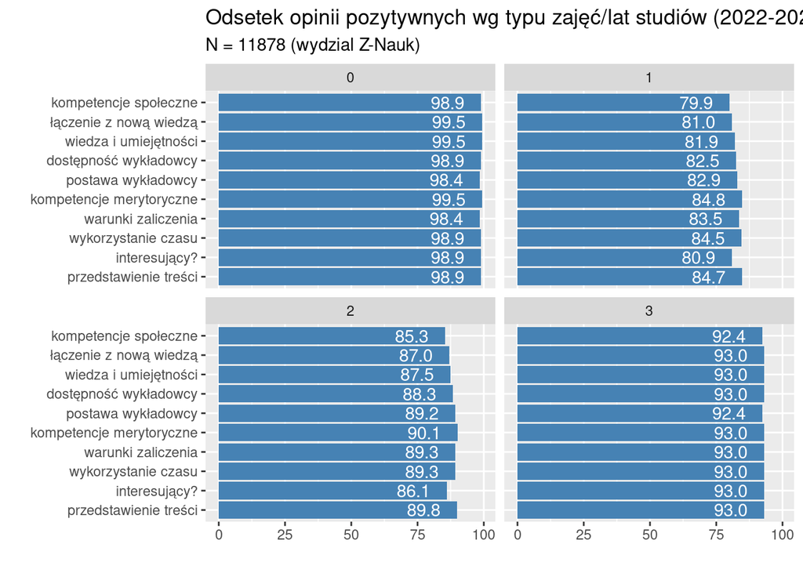

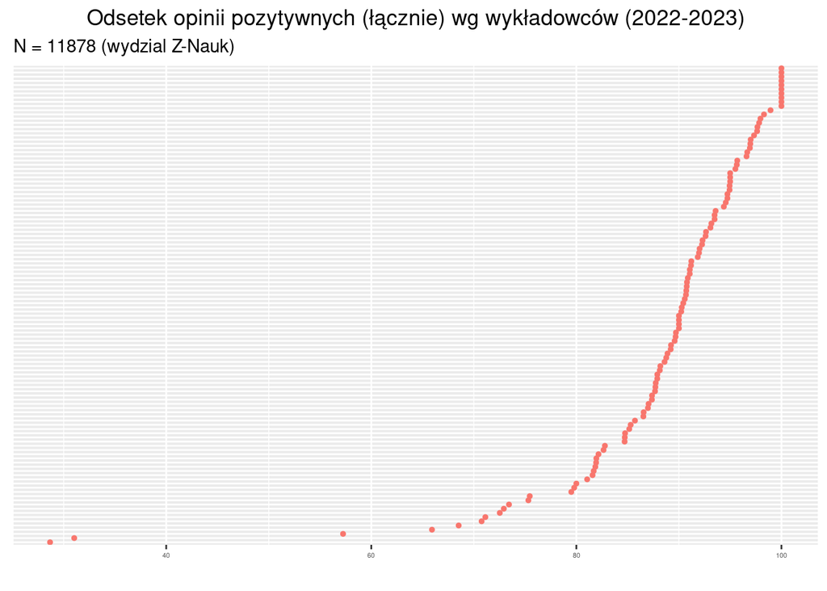

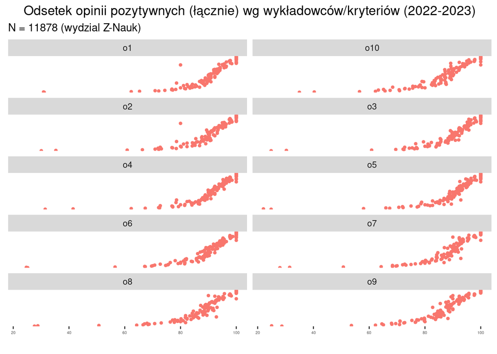

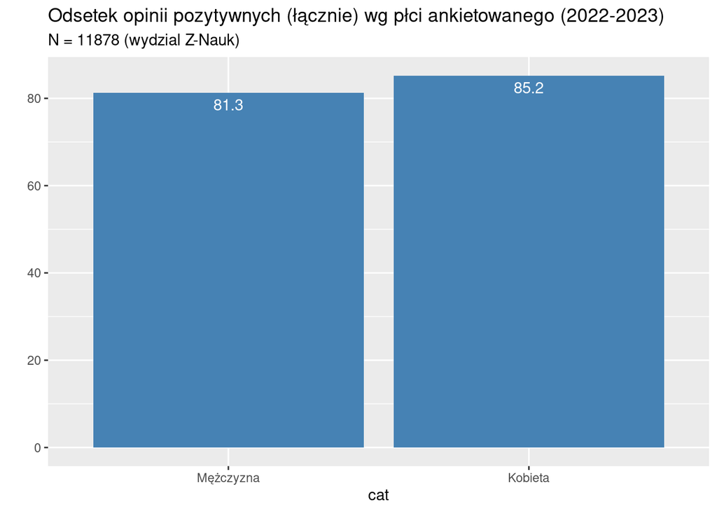

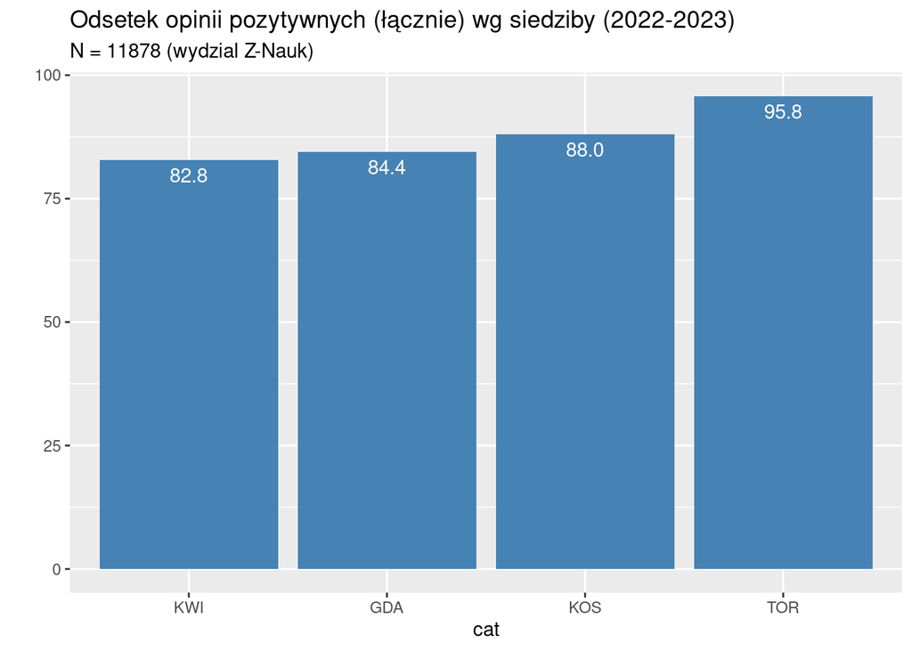

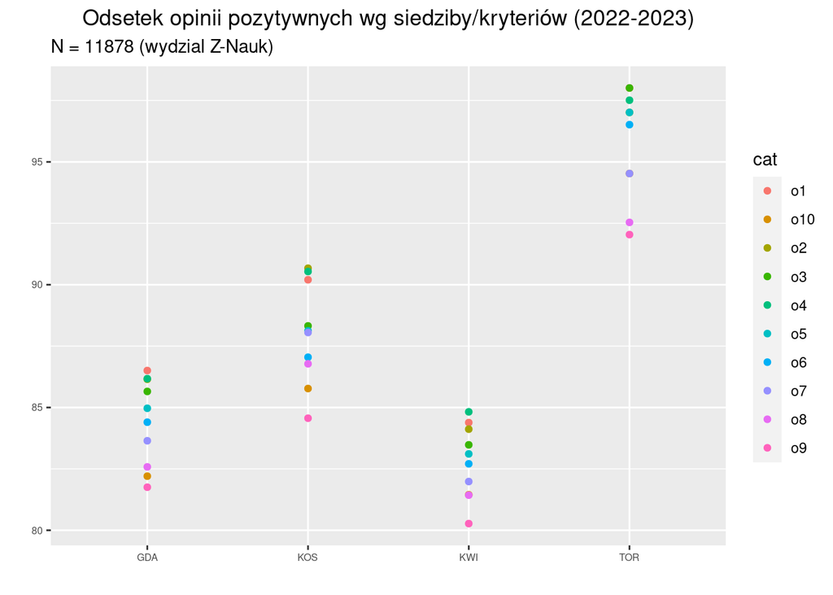

## Formularz ankiety oceny jakości zajęć

1. Nazwa przedmiotu
2. Imię i nazwisko wykładowcy
3. Forma zajęć

Proszę o ocenę zajęć pod względem następujących kryteriów (Odpowiedzi na pytania 4–12 w skali: **□ zdecydowanie się nie zgadzam □ nie zgadzam się □ ani się zgadzam ani się nie zgadzam □ zgadzam się □ zdecydowanie się zgadzam**; pytanie 13 w skali: **uważam za bardzo mało interesujący □ uważam za mało interesujący □ nie mam zdania □ uważam za interesujący □ uważam za bardzo interesujący**)

4. Jak Pan/Pani ocenia sposób przedstawienia treści zajęć
5. Jak Pan/Pani ocenia wykorzystanie czasu pracy
6. Jak Pan/Pani ocenia przedstawienie warunków uzyskania zaliczenia
7. Jak Pan/Pani ocenia kompetencje merytoryczne wykładowcy do prowadzenia zajęć
8. Jak Pan/Pani ocenia postawę wykładowcy wobec studentów
9. Jak Pan/Pani ocenia dostępność wykładowcy dla studentów
10. W mojej opinii zajęcia poszerzyły moją wiedzę i umiejętności
11. W mojej opinii zajęcia umożliwiły łączenie mojej wiedzy i doświadczeń z nową wiedzą i umiejętnościami
12. W mojej opinii zajęcia rozwinęły moje kompetencjie społeczne
13. Czy uważa Pani/Pan przedmiot zajęć za interesujący i warty poznania czy raczej Pani/Pan bierze udział w zajęciach żeby uzyskać zaliczenie
14. Rok studiów
15. Tryb (stacjonarne/niestacjonarne)
16. Kierunek
17. Płeć
18. Miejsce studiowania (Kwidzyn/Filia Gdańsk)